# assignment-4

Gage Clawson

11/13/2018

```r
# read in the lobster traps dataset
lob_traps <- as.data.frame(read_csv("lobster_traps.csv"))
# Read in the lobster size data set and make it tidy

lob_size <- read_csv("lobster_size_abundance.csv")
lob_size1 <- as.data.frame(lob_size)

lob_size2 <- expand.dft(lob_size1, freq = "COUNT") ##expand.dft filters out all count = 0 rows and makes data tidy (each observation has it's own row)
```

Yes boss

```r
lob_size3 <- mutate(lob_size2, DATE = as.Date(DATE, format = '%d-%b-%y')) # make date formats same for both datasets yyyy-mm-dd

three_sites <- c("AQUE", "CARP", "MOHK")

lob_traps1 <- mutate(lob_traps, DATE = as.Date(DATE, format = '%m/%d/%y')) %>%
  filter(SITE %in% three_sites, TRAPS != 0) %>%
    expand.dft(freq = "TRAPS")



# make date formats the same and filter for only the 5 sites
```

1. Lobster abundance and fishing pressure (2012 - 2017) Describe trends in lobster abundance (counts) and fishing pressure (trap buoys) at the five locations from 2012 - 2017. Ignore transect information - we are only interested in evaluating abundance and pressure on the order of SITE. Note: you are not expected to use regression here - just think of ways to clearly describe annual totals visually and in text, noting important trends, events and differences.

```r
# find the counts of lobsters per each site per each year
lob_counts <- lob_size3 %>%
  group_by(SITE, YEAR) %>%
  dplyr::summarise(count_lobs = length(SIZE))


# find the counts of traps per each site per each year
trap_counts <- lob_traps1 %>%
  group_by(SITE, YEAR) %>%
  dplyr::summarise(count_traps = length(OBSERVER))



new_lob_traps <- left_join(lob_counts, trap_counts, by = c("YEAR", "SITE"))
new_lob_traps[is.na(new_lob_traps)] <- 0  ## new_lob_traps is the final table for counts per each site per each year for number of lobsters and traps
```

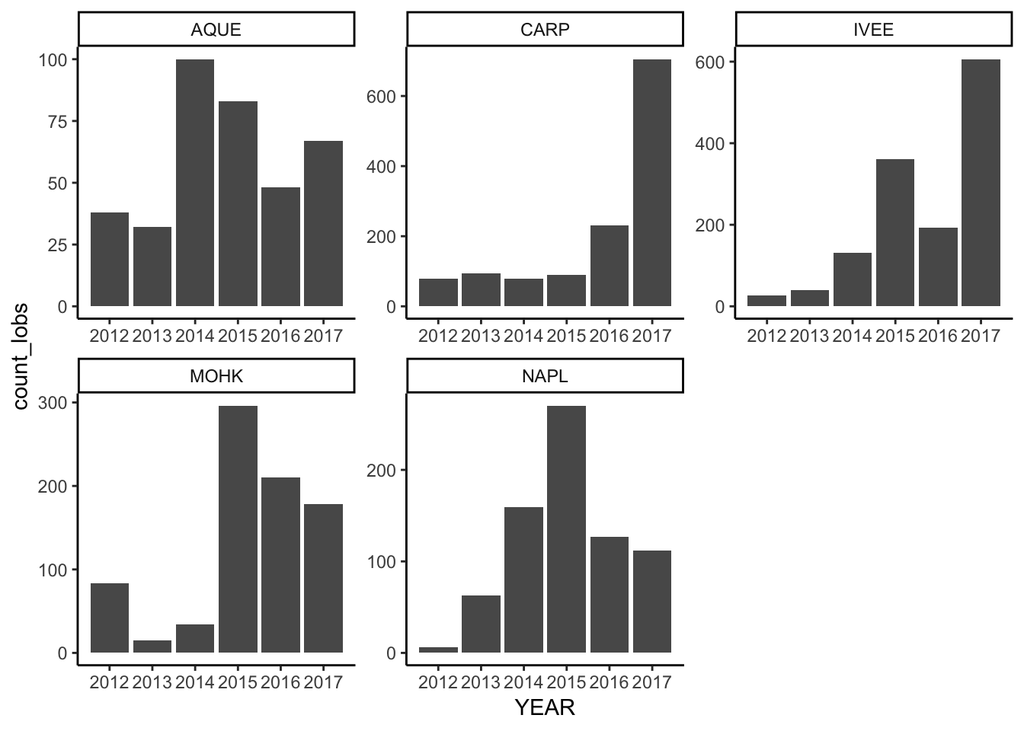

```r
# graphs displaying trends

ggplot(new_lob_traps, aes(x = YEAR, y = count_lobs)) +
  geom_col() +
  facet_wrap(~SITE, scales = "free") +
  theme_classic() +
  scale_x_continuous(breaks = seq(2012,2017, by = 1))
```

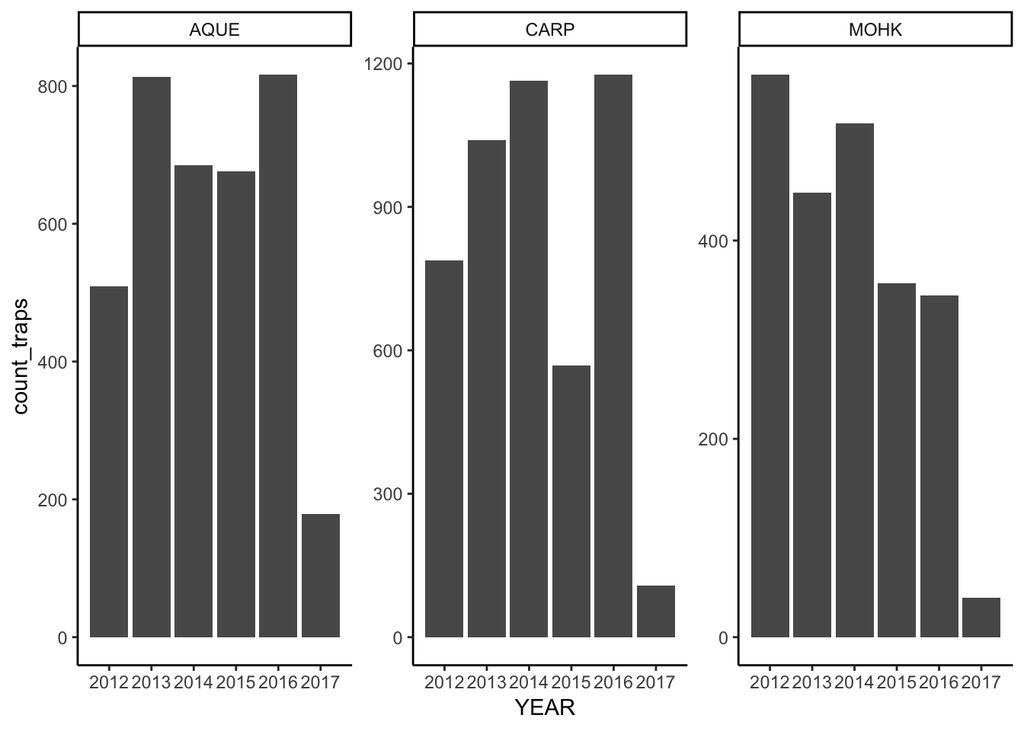

```r
ggplot(trap_counts, aes(x = YEAR, y = count_traps)) +
  geom_col() +
  facet_wrap(~SITE, scales = "free") +
  theme_classic() +
  scale_x_continuous(breaks = seq(2012,2017, by = 1))
```

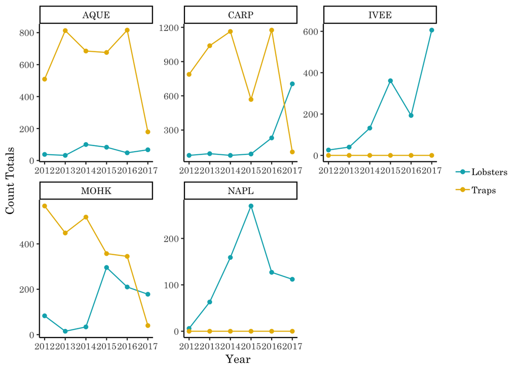

```r
## line graph of lobster vs trap counts per each year per each site
lob_vs_trap_counts <- ggplot(new_lob_traps, aes(x = YEAR)) +
  geom_line(aes(y = count_lobs, color = "blue")) +
  geom_point(aes(y = count_lobs, color = "blue")) +
  geom_line(aes(y = count_traps, color = "red")) +
  geom_point(aes(y = count_traps, color = "red")) +
  facet_wrap(~SITE, scales = "free") +
  theme_classic() +
  scale_color_manual(values = c("#00AFBB", "#E7B800"), name = "Count", labels = c("Lobsters", "Traps")) +
  labs(x = "Year", y = "Count Totals") +
  theme(text = element_text(family = "Century Schoolbook"), legend.title=element_blank())

lob_vs_trap_counts
```

```r
## add caption to graph to explain what is contained within it.
```

**Figure 1. Lobster abundance and fishing pressurein five Long-Term Ecological Research Sites (2012-2017).** The graphs show the trends in lobster counts and trap buoys at five locations Arroyo Quemado (AQUE), Carpinteria (CARP),Isla Vista (IVEE),Mohawk Reef (MOHK), Naples Reef(NAPL) in the Santa Barbara Channel between 2012 and 2017. Blue and yellow lines indicate lobster and trap buoy counts, respectively.

```r
mpa <- c("IVEE", "NAPL")

'%!in%' <- function(x,y)!('%in%'(x,y))

lob_mean <- lob_size3 %>%
  filter(YEAR == 2017) %>%
  mutate(Area = case_when( SITE %in% mpa ~ 'Marine Protected',
                           SITE %!in% mpa ~ 'Non Marine Protected')) %>%
  group_by(SITE, Area) %>%
  dplyr::summarise(mean_size = mean(SIZE), sample_size = length(SIZE), sd_size = sd(SIZE))

lob_size_2017 <- lob_size3 %>%
  filter(YEAR == 2017) %>%
  select(YEAR, SITE, SIZE)
```

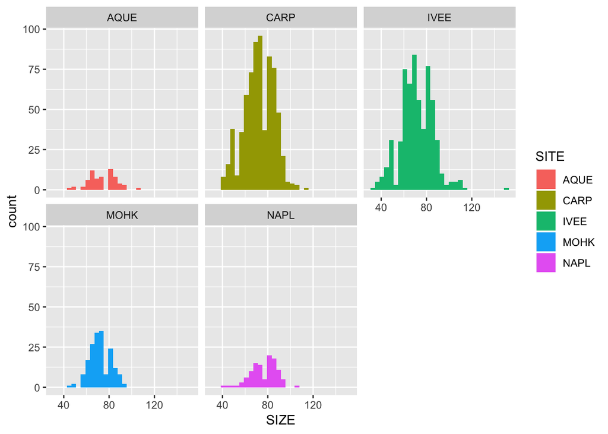

```r
##exploratory graphs

hists <- ggplot(lob_size_2017, aes(x = SIZE)) +
  geom_histogram(aes(fill = SITE)) +
  facet_wrap(~SITE)

hists
```

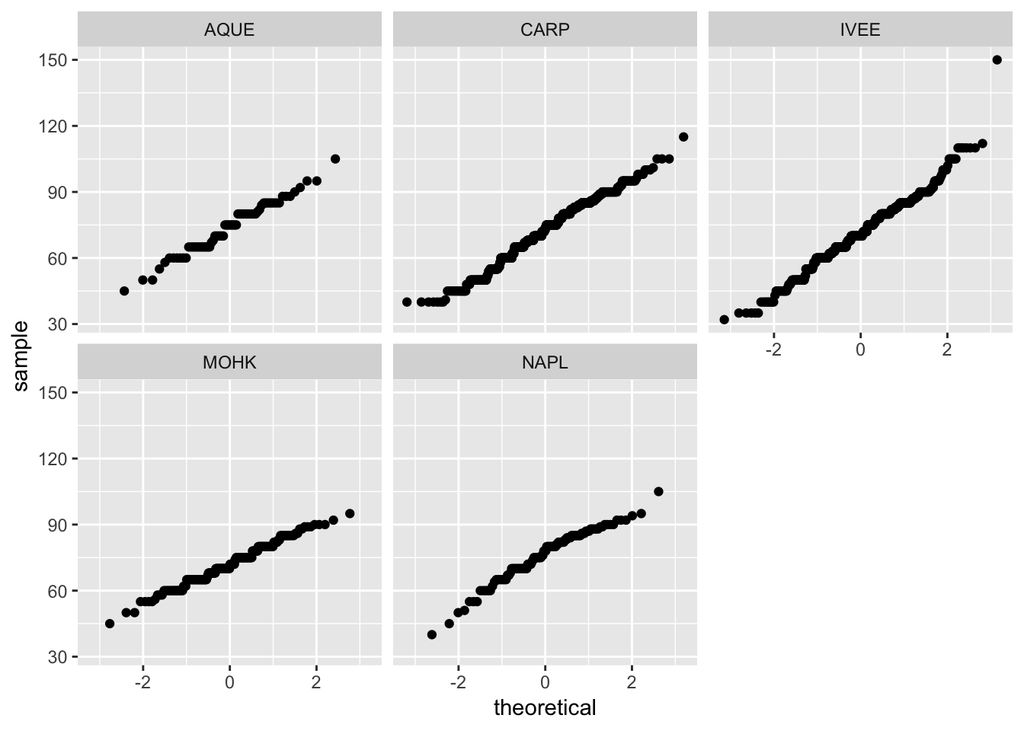

```r
qq <- ggplot(lob_size_2017, aes(sample = SIZE)) +
  geom_qq() +
  facet_wrap(~SITE)

qq
```

```r
## histogram and qqplots indicate normality

# Levene's test for equal variances
# We'll use the function leveneTest from the 'car' package

# H0: Variances are equal
# HA: Variances are unequal

lobster_levene <- leveneTest(SIZE ~ SITE, data = lob_size_2017)
lobster_levene
```

```
## Levene's Test for Homogeneity of Variance (center = median)
##         Df F value    Pr(>F)
## group    4  8.3893 1.065e-06 ***
##       1663
## ---
## Signif. codes:  0 '***' 0.001 '**' 0.01 '*' 0.05 '.' 0.1 ' ' 1
```

```r
# we reject the null hypothesis of equal variances (p < 0.05)

var_table <- lob_size_2017 %>%
  group_by(SITE) %>%
  dplyr::summarise(variance = var(SIZE))

# since largest variance < 4X larger than the smallest variance, can still use ANOVA
```

```r
lobster_aov <- aov(SIZE ~ SITE, data = lob_size_2017)
new_lobster_aov <- summary(lobster_aov)


# H0: Mean sizes across all sites are equal
# HA: There is at least one significant difference in means between the 5 sites

# reject the null

# At least two samples were taken from populations with different means. Which ones are different? All three are different from eachother? Or something else?


# Post hoc testing using Tukey's HSD

lobster_ph <- TukeyHSD(lobster_aov)
lobster_ph
```

```
##   Tukey multiple comparisons of means
##     95% family-wise confidence level
##
## Fit: aov(formula = SIZE ~ SITE, data = lob_size_2017)
##
## $SITE
##                 diff         lwr      upr     p adj
## CARP-AQUE -1.6657352 -6.24294710 2.911477 0.8582355
## IVEE-AQUE -2.4433772 -7.05292315 2.166169 0.5968998
## MOHK-AQUE -1.8955224 -7.02720717 3.236162 0.8514711
## NAPL-AQUE  2.3366205 -3.19311600 7.866357 0.7775633
## IVEE-CARP -0.7776420 -2.76097123 1.205687 0.8216104
## MOHK-CARP -0.2297872 -3.23309697 2.773523 0.9995765
## NAPL-CARP  4.0023556  0.36042398 7.644287 0.0228728
## MOHK-IVEE  0.5478548 -2.50450730 3.600217 0.9882889
## NAPL-IVEE  4.7799976  1.09751057 8.462485 0.0037001
## NAPL-MOHK  4.2321429 -0.08607271 8.550358 0.0579286
```

```r
tukey_data <- as.data.frame(lobster_ph$SITE)


## only significant differences between Naples and Carp, and Naples and IV
```

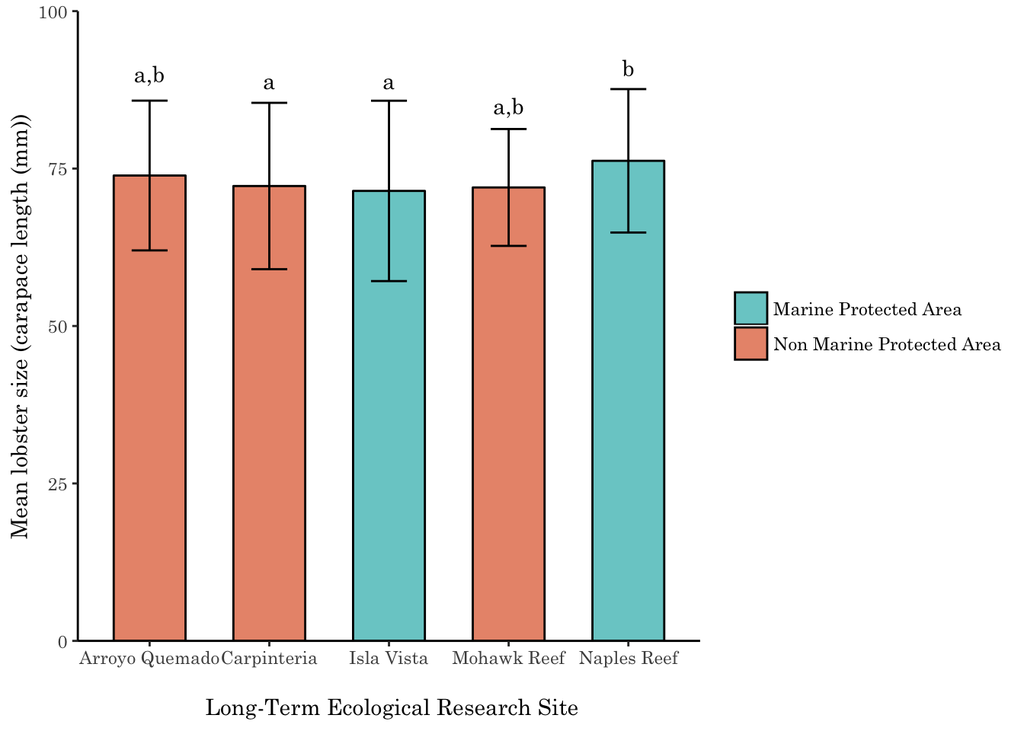

```r
ggplot(lob_mean, aes(x = SITE, y = mean_size)) +
  geom_col(colour = "gray0",aes(fill = Area, width = 0.6)) +
  geom_errorbar(aes(ymin =mean_size - sd_size, ymax = mean_size + sd_size), color = "gray0", width = .3) +
  scale_y_continuous(expand = c(0,0), limits = c(0,100)) +
  scale_x_discrete(labels = c("Arroyo Quemado","Carpinteria","Isla Vista","Mohawk Reef","Naples Reef")) +
  annotate("text", x = 1, y = 90, label = "a,b", family = "Century Schoolbook") +
  annotate("text", x = 2, y = 89, label = "a", family = "Century Schoolbook") +
  annotate("text", x = 3, y = 89, label = "a", family = "Century Schoolbook") +
  annotate("text", x = 4, y = 85, label = "a,b", family = "Century Schoolbook") +
  annotate("text", x = 5, y = 91, label = "b", family = "Century Schoolbook") +
  theme(panel.grid.major = element_blank(), panel.grid.minor = element_blank(),
        panel.background = element_blank(), axis.line = element_line(colour = "black"),text = element_text(family = "Century Schoolbook"), legend.title=element_blank())+
  xlab("\n Long-Term Ecological Research Site")+
  ylab("Mean lobster size (carapace length (mm))") +
  scale_fill_manual(values = c("darkslategray3", "darksalmon"), name = "Area", labels = c(" Marine Protected Area", " Non Marine Protected Area"))#we can change this title
```

3. Changes in lobster size at MPA and non-MPA sites (comparing only 2012 and 2017 sizes) From the data description (http://sbc.lternet.edu/cgi-bin/showDataset.cgi?docid=knb-lter-sbc.77): “Data on abundance, size and fishing pressure of California spiny lobster (Panulirus interruptus) are collected along the mainland coast of the Santa Barbara Channel. Spiny lobsters are an important predator in giant kelp forests off southern California. Two SBC LTER study reefs are located in or near the California Fish and Game Network of Marine Protected Areas (MPA), Naples and Isla Vista, both established as MPAs on 2012-01-01. MPAs provide a unique opportunity to investigate the effects of fishing on kelp forest community dynamics. Sampling began in 2012 and is ongoing.” At Isla Vista and Naples Reef, the two protected MPA sites (with zero fishing pressure), how do lobster sizes in 2012 and 2017 compare? At the non-MPA sites?

```r
mpa <- c("IVEE", "NAPL")

'%!in%' <- function(x,y)!('%in%'(x,y))

## filter for mpa sites and 2017 or 2012

mpa_site <- lob_size3 %>%
  filter(SITE %in% mpa, YEAR == 2012|YEAR == 2017) %>%
  select(SITE,YEAR,SIZE)

## filter for non mpa sites and 2017 or 2012
non_mpa_site <- lob_size3 %>%
  filter(SITE %!in% mpa, YEAR==2012|YEAR==2017) %>%
  select(SITE,YEAR,SIZE)
```

```r
# sandro talked to allison and apparently we have to do 5 different t tests for EACH SITE, instead of only one ttest for MPA and non mpa

# these are datasets for our five different t-tests

mpa_2012 <- lob_size3 %>%
  filter(SITE %in% mpa, YEAR == 2012) %>%
  select(SITE,YEAR,SIZE) %>%
  mutate( i = row_number()) %>%
  spread(SITE,SIZE) %>%
  select(-i)

mpa_2017 <- lob_size3 %>%
  filter(SITE %in% mpa, YEAR == 2017) %>%
  select(SITE,YEAR,SIZE) %>%
  mutate( i = row_number()) %>%
  spread(SITE,SIZE) %>%
  select(-i)

non_mpa_2012 <- lob_size3 %>%
  filter(SITE %!in% mpa, YEAR == 2012) %>%
  select(SITE,YEAR,SIZE) %>%
  mutate( i = row_number()) %>%
  spread(SITE,SIZE) %>%
  select(-i)

non_mpa_2017 <- lob_size3 %>%
  filter(SITE %!in% mpa, YEAR == 2017) %>%
  select(SITE,YEAR,SIZE) %>%
  mutate( i = row_number()) %>%
  spread(SITE,SIZE) %>%
  select(-i)
```

```r
############### MPA SITE IVEE ################

####### F test for equal variances for IVEE 2012 vs 2017 #######

# H0: The variances are equal (ratio of variances = 1)
# HA: The variances are not equal (ratio of variances != 1)

IVEE_ftest <- var.test(mpa_2012$IVEE, mpa_2017$IVEE)

IVEE_ftest
```

```
##
##  F test to compare two variances
##
## data:  mpa_2012$IVEE and mpa_2017$IVEE
## F = 0.71311, num df = 25, denom df = 605, p-value = 0.307
## alternative hypothesis: true ratio of variances is not equal to 1
## 95 percent confidence interval:
##  0.4322948 1.3698611
## sample estimates:
## ratio of variances
##           0.713111
```

```r
# retain the null hypothesis of equal variances

# We can override the default setting in t.test() function of var.equal = FALSE, because the variances are actually likely equal.

# H0: mean Lobster size at IVEE site in 2012 is equal to mean lobster size at IVEE site in 2017
# HA: mean Lobster size at IVEE site in 2012 is NOT equal to mean lobster size at IVEE site in 2017

IVEE_ttest <- t.test(mpa_2012$IVEE, mpa_2017$IVEE, var.equal = TRUE)

IVEE_ttest # retain null they are equal, p =0.0599
```

```
##
##  Two Sample t-test
##
## data:  mpa_2012$IVEE and mpa_2017$IVEE
## t = -1.885, df = 630, p-value = 0.0599
## alternative hypothesis: true difference in means is not equal to 0
## 95 percent confidence interval:
##  -10.9750916   0.2246473
## sample estimates:
## mean of x mean of y
##  66.07692  71.45215
```

```r
#calculate the difference in means at IVEE 2012 and 2017

IVEE_mean_2012 <- mean(mpa_2012$IVEE, na.rm = TRUE)

IVEE_mean_2017 <- mean(mpa_2017$IVEE, na.rm = TRUE)

IVEE_mean_2012 - IVEE_mean_2017
```

```
## [1] -5.375222
```

```r
## difference in means is -5.375222 mm


# calculate effect size
IVEE_cohen_d <- cohen.d(mpa_2012$IVEE, mpa_2017$IVEE, na.rm = TRUE)
IVEE_cohen_d
```

```
##
## Cohen's d
##
## d estimate: -0.3775177 (small)
## 95 percent confidence interval:
##         inf         sup
## -0.77136540  0.01633002
```

```r
sd(mpa_2012$IVEE, na.rm = TRUE)
```

```
## [1] 12.09272
```

```r
# IVEE 2012 sd: 12.09272
length(mpa_2012$IVEE[!is.na(mpa_2012$IVEE)])
```

```
## [1] 26
```

```r
# IVEE 2012 n: 26

sd(mpa_2017$IVEE, na.rm = TRUE)
```

```
## [1] 14.32008
```

```r
# IVEE 2012 sd: 14.32008
length(mpa_2017$IVEE[!is.na(mpa_2017$IVEE)])
```

```
## [1] 606
```

```r
# IVEE 2012 n: 606

## effect size is small (d = -0.3775177) which indicates that there likely is NOT a significant difference in mean lobster size between the two years.
```

The mean lobster size at Isla Vista (Marine Protected Area) in 2012 (66.08 ± 12.09 mm [mean±sd], n=26 ) and 2017 (71.45 ± 14.32 mm [mean±sd], n=606 ) did not differ significantly based on a two-sample Student’s t-test (t(630) = -1.89, p = 0.060, α = 0.05). Also, the effect size is small (Cohen’s d = -0.38) and the absolute difference in mean lobster size between the two years is 5.38 mm.

```r
############### MPA SITE NAPL ################

####### F test for equal variances for NAPL 2012 vs 2017 #######

# H0: The variances are equal (ratio of variances = 1)
# HA: The variances are not equal (ratio of variances != 1)

NAPL_ftest <- var.test(mpa_2012$NAPL, mpa_2017$NAPL)

NAPL_ftest
```

```
##
##  F test to compare two variances
##
## data:  mpa_2012$NAPL and mpa_2017$NAPL
## F = 1.064, num df = 5, denom df = 111, p-value = 0.7685
## alternative hypothesis: true ratio of variances is not equal to 1
## 95 percent confidence interval:
##  0.3966019 6.4626426
## sample estimates:
## ratio of variances
##           1.064048
```

```r
# retain the null hypothesis of equal variances

# We can override the default setting in t.test() function of var.equal = FALSE, because the variances are actually likely equal.

# H0: mean Lobster size at NAPL site in 2012 is equal to mean lobster size at NAPL site in 2017
# HA: mean Lobster size at NAPL site in 2012 is NOT equal to mean lobster size at NAPL site in 2017

NAPL_ttest <- t.test(mpa_2012$NAPL, mpa_2017$NAPL, var.equal = TRUE)

NAPL_ttest # retain null they are equal, p =0.5002
```

```
##
##  Two Sample t-test
##
## data:  mpa_2012$NAPL and mpa_2017$NAPL
## t = -0.67636, df = 116, p-value = 0.5002
## alternative hypothesis: true difference in means is not equal to 0
## 95 percent confidence interval:
##  -12.697051   6.232765
## sample estimates:
## mean of x mean of y
##  73.00000  76.23214
```

```r
#calculate the difference in means at NAPL 2012 and 2017

NAPL_mean_2012 <- mean(mpa_2012$NAPL, na.rm = TRUE)

NAPL_mean_2017 <- mean(mpa_2017$NAPL, na.rm = TRUE)

NAPL_mean_2012 - NAPL_mean_2017
```

```
## [1] -3.232143
```

```r
## difference in means is -3.232143 mm


# calculate effect size
NAPL_cohen_d <- cohen.d(mpa_2012$NAPL, mpa_2017$NAPL, na.rm = TRUE)
NAPL_cohen_d
```

```
##
## Cohen's d
##
## d estimate: -0.2834216 (small)
## 95 percent confidence interval:
##        inf        sup
## -1.1141889  0.5473456
```

```r
## effect size is small (d = -0.2834216) which indicates that there likely is NOT a significant difference in mean lobster size between the two years.

sd(mpa_2012$NAPL, na.rm = TRUE)
```

```
## [1] 11.74734
```

```r
# NAPL 2012 sd: 11.74734
length(mpa_2012$NAPL[!is.na(mpa_2012$NAPL)])
```

```
## [1] 6
```

```r
# NAPL 2012 n: 6

sd(mpa_2017$NAPL, na.rm = TRUE)
```

```
## [1] 11.3883
```

```r
# NAPL 2012 sd: 11.3883
length(mpa_2017$NAPL[!is.na(mpa_2017$NAPL)])
```

```
## [1] 112
```

```r
# NAPL 2012 n: 112
```

The mean lobster size at Naples Reef (Marine Protected Area) in 2012 (73.00 ± 11.74 mm [mean±sd], n= 6 ) and 2017 ( 76.23± 11.39 mm [mean±sd], n= 112) did not differ significantly based on a two-sample Student’s t-test (t(116) = -0.68, p = 0.500, α = 0.05).Also,the effect size is small (Cohen’s d = -0.28) and the absolute difference in mean lobster size between two years is only 3.232 mm.

```r
############### NON MPA SITE AQUE ################

####### F test for equal variances for AQUE 2012 vs 2017 #######

# H0: The variances are equal (ratio of variances = 1)
# HA: The variances are not equal (ratio of variances != 1)

AQUE_ftest <- var.test(non_mpa_2012$AQUE, non_mpa_2017$AQUE)

AQUE_ftest
```

```
##
##  F test to compare two variances
##
## data:  non_mpa_2012$AQUE and non_mpa_2017$AQUE
## F = 0.72863, num df = 37, denom df = 66, p-value = 0.2986
## alternative hypothesis: true ratio of variances is not equal to 1
## 95 percent confidence interval:
##  0.419142 1.327868
## sample estimates:
## ratio of variances
##          0.7286314
```

```r
# retain the null hypothesis of equal variances

# We can override the default setting in t.test() function of var.equal = FALSE, because the variances are actually likely equal.

# H0: mean Lobster size at AQUE site in 2012 is equal to mean lobster size at AQUE site in 2017
# HA: mean Lobster size at AQUE site in 2012 is NOT equal to mean lobster size at AQUE site in 2017

AQUE_ttest <- t.test(non_mpa_2012$AQUE, non_mpa_2017$AQUE, var.equal = TRUE)

AQUE_ttest # retain null they are equal, p =0.2097
```

```
##
##  Two Sample t-test
##
## data:  non_mpa_2012$AQUE and non_mpa_2017$AQUE
## t = -1.2622, df = 103, p-value = 0.2097
## alternative hypothesis: true difference in means is not equal to 0
## 95 percent confidence interval:
##  -7.445357  1.654312
## sample estimates:
## mean of x mean of y
##  71.00000  73.89552
```

```r
#calculate the difference in means at AQUE 2012 and 2017

AQUE_mean_2012 <- mean(non_mpa_2012$AQUE, na.rm = TRUE)

AQUE_mean_2017 <- mean(non_mpa_2017$AQUE, na.rm = TRUE)

AQUE_mean_2012 - AQUE_mean_2017
```

```
## [1] -2.895522
```

```r
## difference in means is -2.895522 mm


# calculate effect size
AQUE_cohen_d <- cohen.d(non_mpa_2012$AQUE, non_mpa_2017$AQUE, na.rm = TRUE)
AQUE_cohen_d
```

```
##
## Cohen's d
##
## d estimate: -0.2563169 (small)
## 95 percent confidence interval:
##        inf        sup
## -0.6606014  0.1479675
```

```r
## effect size is small (d = -0.2563169) which indicates that there likely is NOT a significant difference in mean lobster size between the two years.

sd(non_mpa_2012$AQUE, na.rm = TRUE)
```

```
## [1] 10.15022
```

```r
# AQUE 2012 sd: 10.15022
length(non_mpa_2012$AQUE[!is.na(non_mpa_2012$AQUE)])
```

```
## [1] 38
```

```r
# AQUE 2012 n: 38

sd(non_mpa_2017$AQUE, na.rm = TRUE)
```

```
## [1] 11.89109
```

```r
# AQUE 2012 sd: 11.89109
length(non_mpa_2017$AQUE[!is.na(non_mpa_2017$AQUE)])
```

```
## [1] 67
```

```r
# AQUE 2012 n: 67
```

The mean lobster size at Arroyo Quemado(non-Marine Protected Area) in 2012 (71.00 ± 10.15 mm [mean±sd], n= 38) and 2017 (73.90 ± 11.89 mm [mean±sd], n=67 ) did not differ significantly based on a two-sample Student’s t-test (t(103) = -1.26, p = 0.210, α = 0.05). Also,the effect size is small (Cohen’s d = -0.26) and the absolute difference in mean lobster size between the two years is only 2.90 mm.

```r
############### NON MPA SITE CARP ################

####### F test for equal variances for CARP 2012 vs 2017 #######

# H0: The variances are equal (ratio of variances = 1)
# HA: The variances are not equal (ratio of variances != 1)

CARP_ftest <- var.test(non_mpa_2012$CARP, non_mpa_2017$CARP)

CARP_ftest
```

```
##
##  F test to compare two variances
##
## data:  non_mpa_2012$CARP and non_mpa_2017$CARP
## F = 1.2244, num df = 77, denom df = 704, p-value = 0.2043
## alternative hypothesis: true ratio of variances is not equal to 1
## 95 percent confidence interval:
##  0.896208 1.750406
## sample estimates:
## ratio of variances
##           1.224405
```

```r
# retain the null hypothesis of equal variances

# We can override the default setting in t.test() function of var.equal = FALSE, because the variances are actually likely equal.

# H0: mean Lobster size at CARP site in 2012 is equal to mean lobster size at CARP site in 2017
# HA: mean Lobster size at CARP site in 2012 is NOT equal to mean lobster size at CARP site in 2017

CARP_ttest <- t.test(non_mpa_2012$CARP, non_mpa_2017$CARP, var.equal = TRUE)

CARP_ttest # retain null they are equal, p =0.1819
```

```
##
##  Two Sample t-test
##
## data:  non_mpa_2012$CARP and non_mpa_2017$CARP
## t = 1.3361, df = 781, p-value = 0.1819
## alternative hypothesis: true difference in means is not equal to 0
## 95 percent confidence interval:
##  -0.998958  5.257332
## sample estimates:
## mean of x mean of y
##  74.35897  72.22979
```

```r
#calculate the difference in means at CARP 2012 and 2017

CARP_mean_2012 <- mean(non_mpa_2012$CARP, na.rm = TRUE)

CARP_mean_2017 <- mean(non_mpa_2017$CARP, na.rm = TRUE)

CARP_mean_2012 - CARP_mean_2017
```

```
## [1] 2.129187
```

```r
## difference in means is 2.129187 mm


# calculate effect size
CARP_cohen_d <- cohen.d(non_mpa_2012$CARP, non_mpa_2017$CARP, na.rm = TRUE)
CARP_cohen_d
```

```
##
## Cohen's d
##
## d estimate: 0.1594364 (negligible)
## 95 percent confidence interval:
##         inf         sup
## -0.07493682  0.39380971
```

```r
## effect size is small (d = 0.1594364) which indicates that there likely is NOT a significant difference in mean lobster size between the two years.

sd(non_mpa_2012$CARP, na.rm = TRUE)
```

```
## [1] 14.61628
```

```r
# CARP 2012 sd: 14.61628
length(non_mpa_2012$CARP[!is.na(non_mpa_2012$CARP)])
```

```
## [1] 78
```

```r
# CARP 2012 n: 78

sd(non_mpa_2017$CARP, na.rm = TRUE)
```

```
## [1] 13.20913
```

```r
# CARP 2012 sd: 13.20913
length(non_mpa_2017$CARP[!is.na(non_mpa_2017$CARP)])
```

```
## [1] 705
```

```r
# CARP 2012 n: 705
```

```r
############### NON MPA SITE MOHK ################

####### F test for equal variances for MOHK 2012 vs 2017 #######

# H0: The variances are equal (ratio of variances = 1)
# HA: The variances are not equal (ratio of variances != 1)

MOHK_ftest <- var.test(non_mpa_2012$MOHK, non_mpa_2017$MOHK)

MOHK_ftest
```

```
##
##  F test to compare two variances
##
## data:  non_mpa_2012$MOHK and non_mpa_2017$MOHK
## F = 1.3015, num df = 82, denom df = 177, p-value = 0.1509
## alternative hypothesis: true ratio of variances is not equal to 1
## 95 percent confidence interval:
##  0.9085131 1.9131403
## sample estimates:
## ratio of variances
##           1.301535
```

```r
# retain the null hypothesis of equal variances

# We can override the default setting in t.test() function of var.equal = FALSE, because the variances are actually likely equal.

# H0: mean Lobster size at MOHK site in 2012 is equal to mean lobster size at MOHK site in 2017
# HA: mean Lobster size at MOHK site in 2012 is NOT equal to mean lobster size at MOHK site in 2017

MOHK_ttest <- t.test(non_mpa_2012$MOHK, non_mpa_2017$MOHK, var.equal = TRUE)

MOHK_ttest # REJECT null they are equal, p = 6.276e-05
```

```
##
##  Two Sample t-test
##
## data:  non_mpa_2012$MOHK and non_mpa_2017$MOHK
## t = 4.0689, df = 259, p-value = 6.276e-05
## alternative hypothesis: true difference in means is not equal to 0
## 95 percent confidence interval:
##  2.710776 7.795248
## sample estimates:
## mean of x mean of y
##  77.25301  72.00000
```

```r
#calculate the difference in means at MOHK 2012 and 2017

MOHK_mean_2012 <- mean(non_mpa_2012$MOHK, na.rm = TRUE)

MOHK_mean_2017 <- mean(non_mpa_2017$MOHK, na.rm = TRUE)

MOHK_mean_2012 - MOHK_mean_2017
```

```
## [1] 5.253012
```

```r
## difference in means is 5.253012 mm


# calculate effect size
MOHK_cohen_d <- cohen.d(non_mpa_2012$MOHK, non_mpa_2017$MOHK, na.rm = TRUE)
MOHK_cohen_d
```

```
##
## Cohen's d
##
## d estimate: 0.5408116 (medium)
## 95 percent confidence interval:
##       inf       sup
## 0.2749635 0.8066597
```

```r
## effect size is MEDIUM (d = 0.5408116) which indicates that there likely is a significant difference in mean lobster size between the two years.

sd(non_mpa_2012$MOHK, na.rm = TRUE)
```

```
## [1] 10.58743
```

```r
# MOHK 2012 sd: 10.58743
length(non_mpa_2012$MOHK[!is.na(non_mpa_2012$MOHK)])
```

```
## [1] 83
```

```r
# MOHK 2012 n: 83

sd(non_mpa_2017$MOHK, na.rm = TRUE)
```

```
## [1] 9.280318
```

```r
# MOHK 2012 sd: 9.280318
length(non_mpa_2017$MOHK[!is.na(non_mpa_2017$MOHK)])
```

```
## [1] 178
```

```r
# MOHK 2012 n: 178
```

The mean lobster size at Mohawk Reef (non-Marine Protected Area) in 2012 (77.25 ± 10.59 mm [mean±sd], n= 83) and 2017 ( 72.00 ± 9.28 mm [mean±sd], n= 178 ) differed significantly based on a two-sample Student’s t-test (t(259) = 4.07, p <0.05, α = 0.05).Also,the effect size is moderate (Cohen’s d = 0.54) and the absolute difference in mean lobster size between the two years is 5.25 mm.

4. Proportions of “legal” lobsters at the 5 sites in 2017 The legal minimum carapace size for lobster is 82.6 mm. What proportion of observed lobsters at each site are above the legal minimum? Does that proportion differ significantly across the 5 sites? Note: We’ll be doing chi-square in labs next week, or go ahead with maximum resourcefulness and check out the chisq.test() function on your own!

```r
# filter for 2017
# filter for above 82.6 mm


legal_min <- lob_size3 %>%
  filter(YEAR == 2017) %>%
  mutate(above_legal = case_when(
    SIZE >= 82.6 ~ 'yes',
    SIZE < 82.6 ~ 'no'
  )) %>%
  count(SITE, above_legal) %>%
  spread(above_legal, n) %>%
  select(-SITE)

rownames(legal_min) <- c("AQUE", "CARP", "IVEE", "MOHK", "NAPL")
legal_prop <- prop.table(as.matrix(legal_min), 1)


above_x2 <- chisq.test(legal_min)

above_x2
```

```
##
##  Pearson's Chi-squared test
##
## data:  legal_min
## X-squared = 18.497, df = 4, p-value = 0.0009864
```

```r
## The proportion does differ significantly between each location.
# there is signficant association between legal lobster size and different test sites
```